# Reproducible Research: Assessment 1

This assignment makes use of data from a personal activity monitoring device. This device collects data at 5 minute intervals through out the day. The data consists of two months of data from an anonymous individual collected during the months of October and November, 2012 and include the number of steps taken in 5 minute intervals each day.

## Loading and preprocessing the data

```r
library(ggplot2)
activity<-read.csv("activity.csv")
```

## What is mean total number of steps taken per day?

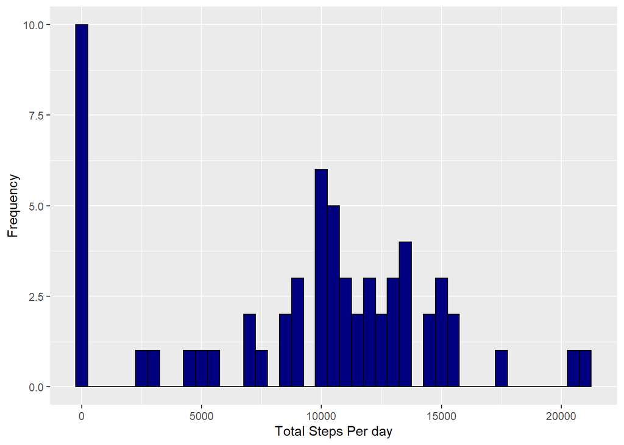

```r
totalStep<-aggregate(steps~date,activity,sum,na.action = na.pass)
totalStep[is.na(totalStep)]<-0
g<-ggplot(totalStep, aes(x=steps))
g+geom_histogram(binwidth = 500,color="black",fill="navy blue")+
    xlab("Total Steps Per day")+
    ylab("Frequency")
```

```r
# Mean of total steps per day
mean(totalStep$steps)
```

```
## [1] 9354.23
```

```r
# Median of total steps per day
median(totalStep$steps)
```

```
## [1] 10395
```

## What is the average daily activity pattern?

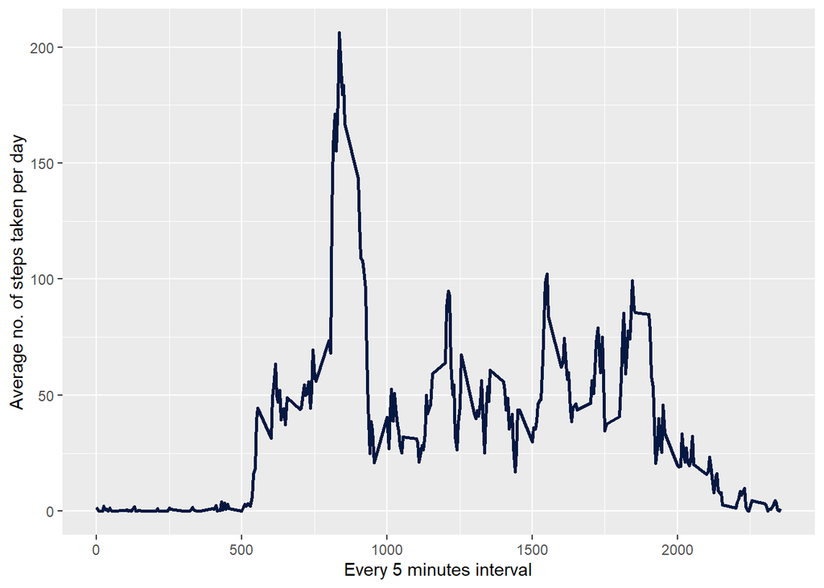

```r
totalStep1<-aggregate(steps~interval,activity,mean)

g<-ggplot(totalStep1,aes(x=interval,y=steps))
g+geom_line(colour="#051841",size=1)+
    xlab("Every 5 minutes interval")+
    ylab("Average no. of steps taken per day")
```

For calculating the 5-minute interval that contains the maximum number of steps

```r
totalStep1[which.max(totalStep1$steps),]
```

```
##     interval    steps
## 104      835 206.1698
```